# Refining graphics 3

## Data

```r
library(tidyverse)
library(ggformula)
library(patchwork)

d <- rio::import("data/labs.xlsx") %>%
tidyr::pivot_wider(values_from = "value", names_from = "var")

head(d, 4)
```

```
# A tibble: 4 × 15
  set    site    subject_id treatment visit glucosa creatinina    Na     K   AST
  <chr>  <chr>        <dbl> <chr>     <chr>   <dbl>      <dbl> <dbl> <dbl> <dbl>
1 SAFETY Clínic…          1 Experime… V0         96        0.7   142   3.5    25
2 SAFETY Clínic…          1 Experime… V3        100        0.7   143   4.1    25
3 SAFETY Clínic…          1 Experime… V4         88        0.6   141   4.2    29
4 SAFETY Clínic…          1 Experime… V5         96        0.7   141   4.1    29
# … with 5 more variables: ALT <dbl>, GGT <dbl>, bilTotal <dbl>, Hb <dbl>,
#   hematocrito <dbl>
```

## Transformations

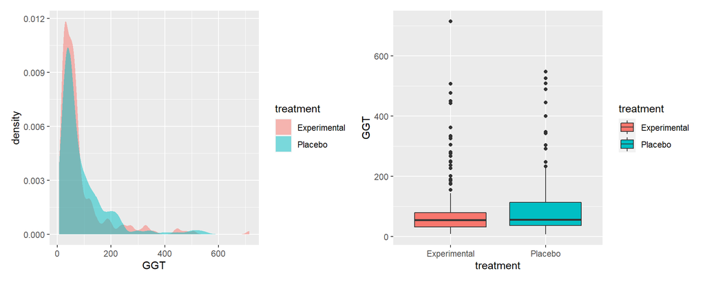

```r
gf_density(~ GGT, data = d, fill = ~treatment) +
gf_boxplot(GGT ~ treatment, data = d, fill = ~treatment)
```

## Transformations of coordinates

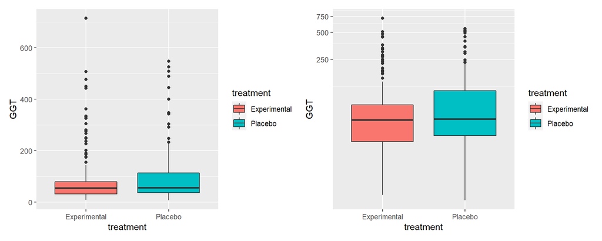

```r
gf_boxplot(GGT ~ treatment, data = d, fill = ~treatment) +
gf_boxplot(GGT ~ treatment, data = d, fill = ~treatment) %>%
  gf_refine(coord_trans(y = "log10"))
```

## Transformations of values

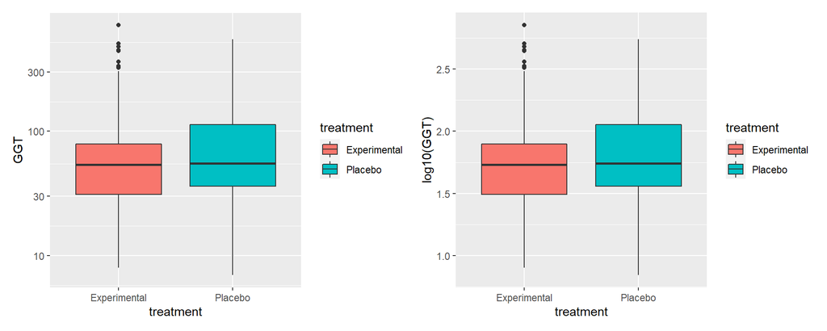

```r
gf_boxplot(GGT ~ treatment, data = d, fill = ~treatment) %>%
  gf_refine(scale_y_log10()) +
gf_boxplot(log10(GGT) ~ treatment, data = d, fill = ~treatment)
```

## Colors

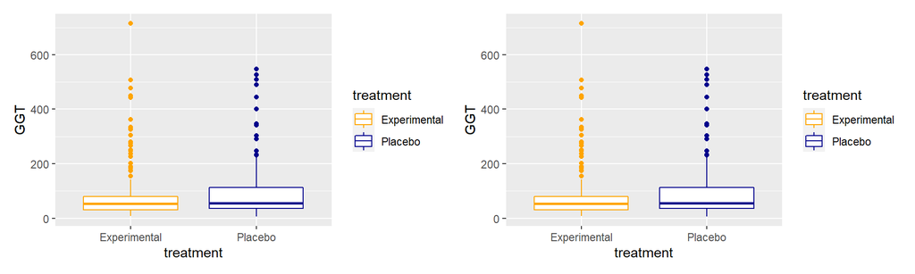

```r
p <- gf_boxplot(GGT ~ treatment, data = d, color = ~treatment)
p %>% gf_refine(scale_color_manual(values = c("orange", "darkblue"))) +
p %>% gf_refine(scale_color_manual(values = c("#FFA500", "#00008B")))
```

- See available color names with `colors()`

## Color palettes \(\quad\) (`RColorBrewer` and more)

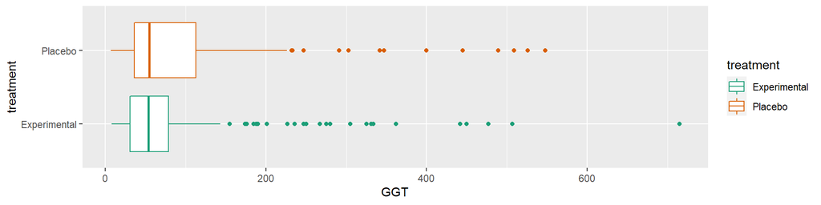

```r
library(RColorBrewer)
p %>% gf_refine(scale_color_brewer(palette="Dark2"),
                coord_flip())
```

- See all RColorBrewer palettes with `RColorBrewer::display.brewer.all()`
- Many other palettes available through package [`paletteer`](https://emilhvitfeldt.github.io/paletteer/)

## More on graphics

`ggformula`: \(\quad\) RStudio tutorials and [this article](http://www.mosaic-web.org/ggformula/articles/pkgdown/ggformula-long.html)

`ggplot2`:

- [A ggplot2 tutorial for beautiful plotting in R](https://www.cedricscherer.com/2019/08/05/a-ggplot2-tutorial-for-beautiful-plotting-in-r/), by Cédric Sherer.
- [Introduction to data visualization with ggplot2](https://www.datacamp.com/courses/introduction-to-data-visualization-with-ggplot2), Datacamp online course.
- [The R graph gallery](https://r-graph-gallery.com/), by Yan Holtz.

`ggpubr`: \(\quad\) [Publication Ready Plots](http://www.sthda.com/english/articles/24-ggpubr-publication-ready-plots/).

Other plotting systems in R: \(\quad\) [Base R](http://www.sthda.com/english/wiki/r-base-graphs) and [`lattice`](http://www.sthda.com/english/wiki/lattice-graphs).

## Exercise

- Run this code to read the `OSAS.xls` data and compute `ccg`, a grouped version of the cervical circumference. In the R graph gallery, look for the type of graphic shown below. Copy the code of the **Most basic ridgeline**, and adapt it to produce the graphic shown below.

```r
d <- rio::import("data/OSAS.xls")  %>%
  mutate(ccg = cut(cervical_circumference, breaks = c(30, 38.5, 41.5, 44, 55)))
```

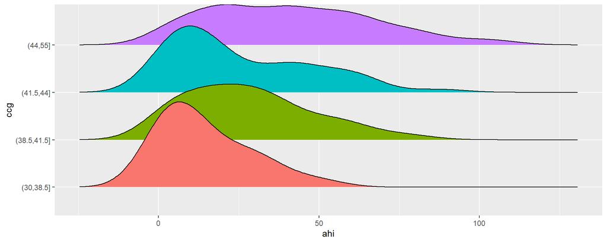

## Exercise (cont.)

- Install package `ggpubr`. Then look at the first example in [this tutorial](http://www.sthda.com/english/articles/24-ggpubr-publication-ready-plots/76-add-p-values-and-significance-levels-to-ggplots/#compare-two-independent-groups), and try to produce the graphics below.

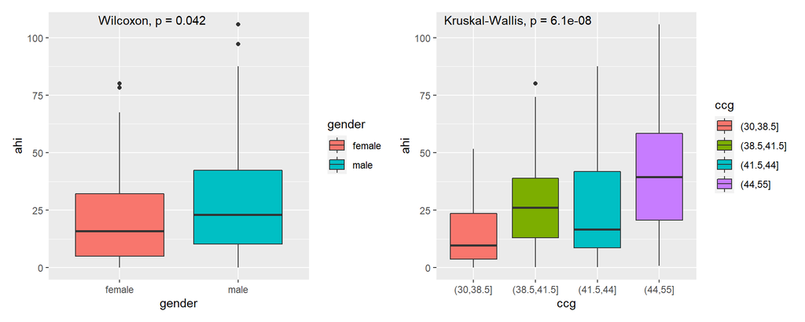

## Review exercise

- Produce this graphic with the `aht.xls` data.  
  Hint: use `show_col(hue_pal()(2))` to see how to specify the colors for the reference lines.

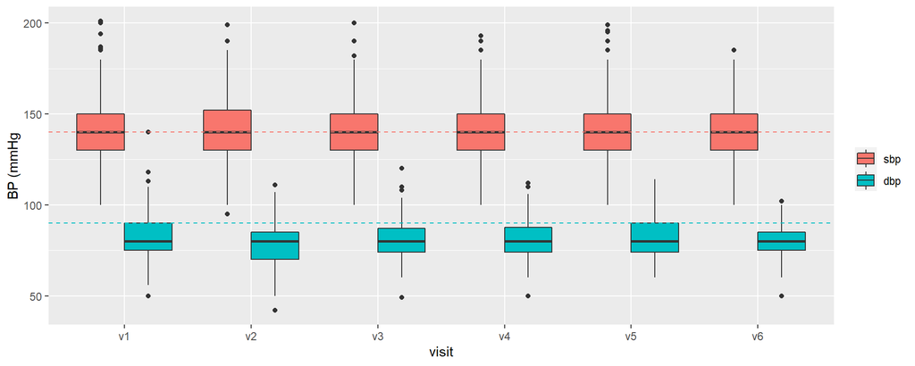